# ICE Development - Study 2 - data analysis

Michalina Marczak

Last compiled on 12 September, 2023

## Inspecting the climate emotions data

### Distributions of climate emotions data

Let’s check the assumptions for Confirmatory Factor Analysis (CFA): multi- & uni-variate normality check. We will perform formal tests: Mardia’s test for multivariate skewness and kurtosis & Shapiro-Wilk for univariate normality.

#### Formal tests

```
## $mv.test
##           Test Statistic p-value Result
## 1     Skewness 56171.858       0     NO
## 2     Kurtosis   48.9087       0     NO
## 3 MV Normality      <NA>    <NA>     NO
##
## $uv.shapiro
##                  W      p-value UV.Normality
## ICE.60.pl.ANG14  0.8377 0       No
## ICE.60.pl.ANG13  0.8156 0       No
## ICE.60.pl.ANG10  0.8249 0       No
## ICE.60.pl.ANG5   0.8103 0       No
## ICE.60.pl.ANG6   0.7982 0       No
## ICE.60.pl.ANG8   0.7827 0       No
## ICE.60.pl.ANG3   0.8233 0       No
## ICE.60.pl.ANG1   0.809  0       No
## ICE.60.pl.IND7   0.8263 0       No
## ICE.60.pl.DIS5   0.8866 0       No
## ICE.60.pl.DIS13  0.8723 0       No
## ICE.60.pl.DIS10  0.7652 0       No
## ICE.60.pl.IND6   0.7778 0       No
## ICE.60.pl.DIS7   0.7926 0       No
## ICE.60.pl.IND2   0.8057 0       No
## ICE.60.pl.IND13  0.8719 0       No
## ICE.60.pl.EMP12  0.8213 0       No
## ICE.60.pl.EMP9   0.8388 0       No
## ICE.60.pl.HOPF9  0.859  0       No
## ICE.60.pl.HOPF8  0.8679 0       No
## ICE.60.pl.HOPF10 0.9064 0       No
## ICE.60.pl.EMP14  0.7964 0       No
## ICE.60.pl.HOPF13 0.8931 0       No
## ICE.60.pl.EMP7   0.8411 0       No
## ICE.60.pl.POWL11 0.9011 0       No
## ICE.60.pl.POWL5  0.8797 0       No
## ICE.60.pl.POWL7  0.8897 0       No
## ICE.60.pl.POWL4  0.8866 0       No
## ICE.60.pl.POWL8  0.8804 0       No
## ICE.60.pl.POWL12 0.8903 0       No
## ICE.60.pl.POWL2  0.8739 0       No
## ICE.60.pl.POWL13 0.8927 0       No
```

[output cut: 13 more lines]

```
## ICE.60.pl.ISO12  0.9013 0       No
## ICE.60.pl.ISO2   0.8792 0       No
## ICE.60.pl.ISO9   0.9002 0       No
## ICE.60.pl.APP10  0.8223 0       No
## ICE.60.pl.HOPL7  0.903  0       No
## ICE.60.pl.HOPL1  0.893  0       No
## ICE.60.pl.APP2   0.8178 0       No
## ICE.60.pl.APP7   0.8094 0       No
## ICE.60.pl.HOPL5  0.883  0       No
## ICE.60.pl.HOPL11 0.861  0       No
## ICE.60.pl.APP14  0.8375 0       No
## ICE.60.pl.SOR13  0.6941 0       No
## ICE.60.pl.SOR6   0.7902 0       No
## ICE.60.pl.SOR4   0.8278 0       No
## ICE.60.pl.SOR14  0.7456 0       No
```

The values from the formal tests imply that we should reject the null hypotheses of uni- & multivariate normality.

## Confirmatory Factor Analysis

### The EFA-informed model

We specify the first model informed by the EFA in Study 1.

```r
model <- 'climate_anger =~ ICE.60.pl.ANG14 + ICE.60.pl.ANG13 + ICE.60.pl.ANG10 + ICE.60.pl.ANG5 + ICE.60.pl.ANG6 + ICE.60.pl.ANG8 + ICE.60.pl.ANG3 + ICE.60.pl.ANG1
          climate_contempt =~ ICE.60.pl.IND7 + ICE.60.pl.DIS5 + ICE.60.pl.DIS13 + ICE.60.pl.DIS10 + ICE.60.pl.IND6 + ICE.60.pl.DIS7 + ICE.60.pl.IND2 + ICE.60.pl.IND13
          climate_enthusiasm =~ ICE.60.pl.EMP9 + ICE.60.pl.EMP12 + ICE.60.pl.HOPF9 + ICE.60.pl.HOPF8 + ICE.60.pl.HOPF10 + ICE.60.pl.EMP14 + ICE.60.pl.HOPF13 + ICE.60.pl.EMP7
          climate_powerlessness =~ ICE.60.pl.POWL11 + ICE.60.pl.POWL5 + ICE.60.pl.POWL7 + ICE.60.pl.POWL4 + ICE.60.pl.POWL8 + ICE.60.pl.POWL12 + ICE.60.pl.POWL2 + ICE.60.pl.POWL13
          climate_guilt =~ ICE.60.pl.GUI11 + ICE.60.pl.GUI6 + ICE.60.pl.GUI2 + ICE.60.pl.GUI8 + ICE.60.pl.GUI9 + ICE.60.pl.GUI4 + ICE.60.pl.GUI12 + ICE.60.pl.GUI14
          climate_isolation =~ ICE.60.pl.ISO4+ ICE.60.pl.ISO13 + ICE.60.pl.ISO5 + ICE.60.pl.ISO8 + ICE.60.pl.ISO3 + ICE.60.pl.ISO12 + ICE.60.pl.ISO2 + ICE.60.pl.ISO9
          climate_anxiety =~ ICE.60.pl.APP10 + ICE.60.pl.HOPL7 + ICE.60.pl.HOPL1 + ICE.60.pl.APP2 + ICE.60.pl.APP7 + ICE.60.pl.HOPL5 + ICE.60.pl.HOPL11 + ICE.60.pl.APP14
          climate_sorrow =~ ICE.60.pl.SOR13 + ICE.60.pl.SOR6 + ICE.60.pl.SOR4 + ICE.60.pl.SOR14'
```

We fit the CFA model with Satorra-Bentler MLM because the data deviates significantly from the normal distribution (yet there is no need to use MLR because we have complete data); Let’s inspect the fit indices.

```r
model.fit <- cfa(model, data = ICE_data, estimator = "MLM")
lavaan::fitmeasures(model.fit, fit.measures = c("chisq.scaled", "pvalue.scaled", "df.scaled", "cfi.scaled", "tli.scaled", "rmsea.scaled", "rmsea.ci.lower.scaled", "rmsea.ci.upper.scaled", "srmr"))
```

```
##          chisq.scaled         pvalue.scaled             df.scaled            cfi.scaled            tli.scaled
##              2660.368                 0.000              1682.000                 0.884                 0.878
##          rmsea.scaled rmsea.ci.lower.scaled rmsea.ci.upper.scaled                  srmr
##                 0.044                 0.041                 0.047                 0.091
```

Fit indices indicate room for improvement.

### Localised areas of strain

Let’s inspect potential localised areas of strain, starting from having a look at the matrix of standardised residuals.

As asking for a raw matrix of standardised residuals produces an output with a lot of values, which is difficult to comprehend, we need to make it more human-readable. We want to detect variables that have many high standardised residuals. Let’s get the absolute values of residuals and create a sum of standardised residuals for each item, and print them in a descending order.

|  | items | value |
| --- | --- | --- |
| 28 | cov.ICE.60.pl.POWL4 | 180.35582 |
| 17 | cov.ICE.60.pl.EMP9 | 172.76159 |
| 21 | cov.ICE.60.pl.HOPF10 | 172.54885 |
| 29 | cov.ICE.60.pl.POWL8 | 150.56526 |
| 48 | cov.ICE.60.pl.ISO9 | 138.77334 |
| 13 | cov.ICE.60.pl.IND6 | 131.62196 |
| 35 | cov.ICE.60.pl.GUI2 | 131.23228 |
| 23 | cov.ICE.60.pl.HOPF13 | 126.68014 |
| 38 | cov.ICE.60.pl.GUI4 | 126.29110 |
| 50 | cov.ICE.60.pl.HOPL7 | 121.50297 |
| 12 | cov.ICE.60.pl.DIS10 | 121.12199 |
| 51 | cov.ICE.60.pl.HOPL1 | 117.00569 |
| 52 | cov.ICE.60.pl.APP2 | 109.75097 |
| 11 | cov.ICE.60.pl.DIS13 | 108.47348 |
| 30 | cov.ICE.60.pl.POWL12 | 107.95733 |
| 45 | cov.ICE.60.pl.ISO3 | 106.58449 |
| 49 | cov.ICE.60.pl.APP10 | 100.02038 |
| 19 | cov.ICE.60.pl.HOPF9 | 96.59775 |
| 20 | cov.ICE.60.pl.HOPF8 | 93.66067 |
| 47 | cov.ICE.60.pl.ISO2 | 93.39276 |
| 60 | cov.ICE.60.pl.SOR14 | 91.28272 |
| 8 | cov.ICE.60.pl.ANG1 | 91.13770 |
| 42 | cov.ICE.60.pl.ISO13 | 90.10358 |
| 14 | cov.ICE.60.pl.DIS7 | 88.00910 |
| 57 | cov.ICE.60.pl.SOR13 | 87.93751 |
| 22 | cov.ICE.60.pl.EMP14 | 87.89688 |
| 5 | cov.ICE.60.pl.ANG6 | 87.05976 |
| 9 | cov.ICE.60.pl.IND7 | 85.75968 |
| 54 | cov.ICE.60.pl.HOPL5 | 85.65471 |
| 56 | cov.ICE.60.pl.APP14 | 85.64193 |
| 10 | cov.ICE.60.pl.DIS5 | 85.50315 |
| 6 | cov.ICE.60.pl.ANG8 | 85.43078 |
| 40 | cov.ICE.60.pl.GUI14 | 84.28260 |
| 58 | cov.ICE.60.pl.SOR6 | 83.53276 |
| 4 | cov.ICE.60.pl.ANG5 | 83.04319 |
| 7 | cov.ICE.60.pl.ANG3 | 82.93477 |
| 55 | cov.ICE.60.pl.HOPL11 | 82.11460 |
| 37 | cov.ICE.60.pl.GUI9 | 81.55746 |
| 1 | cov.ICE.60.pl.ANG14 | 80.91231 |
| 53 | cov.ICE.60.pl.APP7 | 79.87673 |
| 15 | cov.ICE.60.pl.IND2 | 79.50136 |
| 41 | cov.ICE.60.pl.ISO4 | 79.33536 |
| 26 | cov.ICE.60.pl.POWL5 | 79.24964 |
| 3 | cov.ICE.60.pl.ANG10 | 78.12981 |
| 18 | cov.ICE.60.pl.EMP12 | 76.93451 |
| 36 | cov.ICE.60.pl.GUI8 | 76.79610 |
| 59 | cov.ICE.60.pl.SOR4 | 76.78071 |
| 34 | cov.ICE.60.pl.GUI6 | 75.74698 |
| 33 | cov.ICE.60.pl.GUI11 | 75.26499 |
| 16 | cov.ICE.60.pl.IND13 | 75.08304 |
| 2 | cov.ICE.60.pl.ANG13 | 74.77514 |
| 39 | cov.ICE.60.pl.GUI12 | 72.01917 |
| 32 | cov.ICE.60.pl.POWL13 | 71.34736 |
| 44 | cov.ICE.60.pl.ISO8 | 68.29647 |
| 43 | cov.ICE.60.pl.ISO5 | 67.69920 |
| 25 | cov.ICE.60.pl.POWL11 | 66.78453 |
| 24 | cov.ICE.60.pl.EMP7 | 66.66349 |
| 46 | cov.ICE.60.pl.ISO12 | 65.69914 |
| 31 | cov.ICE.60.pl.POWL2 | 55.79829 |
| 27 | cov.ICE.60.pl.POWL7 | 52.04971 |

The highest values are the most suspicious.

### Model re-specification

Let’s respecify the model based on a step-wise deletion of indicators with the highest standardised residuals from the previous step, constrained by keeping an equal number of indicators in the ‘double emotions’ factors. Below is the final solution:

```r
model <- 'climate_anger =~ ICE.60.pl.ANG14 + ICE.60.pl.ANG13 + ICE.60.pl.ANG10 + ICE.60.pl.ANG3
          climate_contempt =~ ICE.60.pl.DIS5 + ICE.60.pl.DIS7 + ICE.60.pl.IND2 + ICE.60.pl.IND13
          climate_enthusiasm =~ ICE.60.pl.EMP12 + ICE.60.pl.HOPF9 + ICE.60.pl.HOPF8 + ICE.60.pl.EMP7
          climate_powerlessness =~ ICE.60.pl.POWL11 + ICE.60.pl.POWL7 + ICE.60.pl.POWL2 + ICE.60.pl.POWL13
          climate_guilt =~ ICE.60.pl.GUI11 + ICE.60.pl.GUI6 + ICE.60.pl.GUI8 + ICE.60.pl.GUI12
          climate_isolation =~ ICE.60.pl.ISO4 + ICE.60.pl.ISO5 + ICE.60.pl.ISO8 + ICE.60.pl.ISO12
          climate_anxiety =~ ICE.60.pl.APP7 + ICE.60.pl.HOPL5 + ICE.60.pl.HOPL11 + ICE.60.pl.APP14
          climate_sorrow =~ ICE.60.pl.SOR13 + ICE.60.pl.SOR6 + ICE.60.pl.SOR4 + ICE.60.pl.SOR14'

model.fit <- cfa(model, data = ICE_data, estimator = "MLM")
```

And its fit indices.

```r
lavaan::fitmeasures(model.fit, fit.measures = c("chisq.scaled", "pvalue.scaled", "df.scaled", "cfi.scaled", "tli.scaled", "rmsea.scaled", "rmsea.ci.lower.scaled", "rmsea.ci.upper.scaled", "srmr"))
```

```
##          chisq.scaled         pvalue.scaled             df.scaled            cfi.scaled            tli.scaled
##               527.967                 0.002               436.000                 0.973                 0.970
##          rmsea.scaled rmsea.ci.lower.scaled rmsea.ci.upper.scaled                  srmr
##                 0.027                 0.018                 0.033                 0.050
```

The respecified model has improved. Fit indices indicate that now it fits the data very well.

### Characteristics of the re-specified model

Let’s have a look at the characteristics of the respecified model

#### Full model details

```r
lavaan::summary(model.fit, fit.measures = T, standardized = T)
```

```
## lavaan 0.6.15 ended normally after 74 iterations
##
##   Estimator                                         ML
##   Optimization method                           NLMINB
##   Number of model parameters                        92
##
##   Number of observations                           300
##
## Model Test User Model:
##                                               Standard      Scaled
##   Test Statistic                               690.417     527.967
##   Degrees of freedom                               436         436
##   P-value (Chi-square)                           0.000       0.002
##   Scaling correction factor                                  1.308
##     Satorra-Bentler correction
##
## Model Test Baseline Model:
##
##   Test statistic                              5486.066    3958.858
##   Degrees of freedom                               496         496
##   P-value                                        0.000       0.000
##   Scaling correction factor                                  1.386
##
## User Model versus Baseline Model:
##
##   Comparative Fit Index (CFI)                    0.949       0.973
##   Tucker-Lewis Index (TLI)                       0.942       0.970
##
##   Robust Comparative Fit Index (CFI)                         0.975
##   Robust Tucker-Lewis Index (TLI)                            0.971
##
## Loglikelihood and Information Criteria:
##
##   Loglikelihood user model (H0)             -11674.029  -11674.029
##   Loglikelihood unrestricted model (H1)     -11328.820  -11328.820
##
##   Akaike (AIC)                               23532.058   23532.058
##   Bayesian (BIC)                             23872.806   23872.806
##   Sample-size adjusted Bayesian (SABIC)      23581.036   23581.036
##
```

[output cut: 132 more lines]

```
##    .ICE.60.p.HOPL5    0.484    0.056    8.606    0.000    0.484    0.328
##    .ICE.60..HOPL11    0.541    0.064    8.478    0.000    0.541    0.545
##    .ICE.60.p.APP14    0.406    0.056    7.281    0.000    0.406    0.317
##    .ICE.60.p.SOR13    0.313    0.044    7.065    0.000    0.313    0.428
##    .ICE.60.pl.SOR6    0.440    0.066    6.621    0.000    0.440    0.461
##    .ICE.60.pl.SOR4    0.400    0.051    7.796    0.000    0.400    0.406
##    .ICE.60.p.SOR14    0.252    0.033    7.542    0.000    0.252    0.316
##     climate_anger     0.775    0.100    7.745    0.000    1.000    1.000
##     climate_cntmpt    0.928    0.099    9.383    0.000    1.000    1.000
##     climate_nthssm    0.404    0.073    5.533    0.000    1.000    1.000
##     clmt_pwrlssnss    0.390    0.075    5.231    0.000    1.000    1.000
##     climate_guilt     0.877    0.084   10.392    0.000    1.000    1.000
##     climate_isoltn    0.601    0.097    6.181    0.000    1.000    1.000
##     climate_anxity    0.760    0.105    7.251    0.000    1.000    1.000
##     climate_sorrow    0.419    0.079    5.320    0.000    1.000    1.000
```

All factor loadings are > .4.

#### CFA: Convergent validity - AVE

|  | AVE |
| --- | --- |
| climate_anger | 0.645 |
| climate_contempt | 0.624 |
| climate_enthusiasm | 0.452 |
| climate_powerlessness | 0.314 |
| climate_guilt | 0.607 |
| climate_isolation | 0.539 |
| climate_anxiety | 0.608 |
| climate_sorrow | 0.597 |

Climate powerlessness and climate enthusiasm do not meet the strict criteria for convergent validity: the average variance extracted (AVE) by the latent variables is greater than .5.

#### CFA: Discriminant validity

To gauge the discriminant validity of climate emotions in the CFA framework, let’s compute mean correlations between latent variables and their indicators…

…and the squared factor correlations between the latent variables

| ang.m | cont.m | enth.m | powl.m | gui.m | iso.m | anx.m | sor.m |
| --- | --- | --- | --- | --- | --- | --- | --- |
| 0.853561 | 0.8426677 | 0.7686597 | 0.6935259 | 0.8390591 | 0.8080525 | 0.8352892 | 0.8343059 |

|  | climate_anger | climate_contempt | climate_enthusiasm | climate_powerlessness | climate_guilt | climate_isolation | climate_anxiety | climate_sorrow |
| --- | --- | --- | --- | --- | --- | --- | --- | --- |
| climate_anger | 1.000 | 0.385 | 0.227 | 0.212 | 0.357 | 0.191 | 0.614 | 0.700 |
| climate_contempt | 0.385 | 1.000 | 0.181 | 0.007 | 0.188 | 0.082 | 0.502 | 0.544 |
| climate_enthusiasm | 0.227 | 0.181 | 1.000 | 0.000 | 0.100 | 0.028 | 0.247 | 0.270 |
| climate_powerlessness | 0.212 | 0.007 | 0.000 | 1.000 | 0.391 | 0.291 | 0.191 | 0.190 |
| climate_guilt | 0.357 | 0.188 | 0.100 | 0.391 | 1.000 | 0.405 | 0.472 | 0.339 |
| climate_isolation | 0.191 | 0.082 | 0.028 | 0.291 | 0.405 | 1.000 | 0.305 | 0.127 |
| climate_anxiety | 0.614 | 0.502 | 0.247 | 0.191 | 0.472 | 0.305 | 1.000 | 0.712 |
| climate_sorrow | 0.700 | 0.544 | 0.270 | 0.190 | 0.339 | 0.127 | 0.712 | 1.000 |

## Internal consistencies of climate emotions

Let’s compute the internal consistency of the factors using Raykov’s rho & Cronbach’s alpha.

### Raykov’s coefficient

| clim.emotion | raykov.coefficient |
| --- | --- |
| climate_anger | 0.88 |
| climate_contempt | 0.87 |
| climate_enthusiasm | 0.77 |
| climate_powerlessness | 0.64 |
| climate_guilt | 0.86 |
| climate_isolation | 0.82 |
| climate_anxiety | 0.86 |
| climate_sorrow | 0.85 |

### Cronbach’s alpha coefficient

|  | climate_anger | climate_contempt | climate_enthusiasm | climate_powerlessness | climate_guilt | climate_isolation | climate_anxiety | climate_sorrow |
| --- | --- | --- | --- | --- | --- | --- | --- | --- |
| alpha | 0.88 | 0.86 | 0.77 | 0.64 | 0.86 | 0.82 | 0.86 | 0.85 |

Powerlessness is problematic again.

## Associations with other variables

### Internal consistencies of other relevant scales

Let’s use Cronbach’s alpha coefficient

|  | CCAemo | CCA_exp | Clim_per | Enjoi_nat | Int_pol | Conf_science | Env_threat | Hum_dom | Hum_util | Ecocentric | Hogg_aff | Hogg_impact | Ind_mit | Pol_mit | Eff_self | Eff_col | Pers_glob | Soc_des |
| --- | --- | --- | --- | --- | --- | --- | --- | --- | --- | --- | --- | --- | --- | --- | --- | --- | --- | --- |
| raw_alpha | 0.895640345157581 | 0.792723297363362 | 0.721384119845378 | 0.645605182407092 | 0.585652155410868 | 0.78115041322314 | 0.685510272471838 | 0.794889502762431 | 0.683819364714887 | 0.262671779519718 | 0.87069567484586 | 0.819354667180682 | 0.612633519422975 | 0.800644524968896 | 0.860280647591062 | 0.853115787522017 | 0.878366750374444 | 0.710620854447328 |
| std.alpha | 0.898344167041558 | 0.794270417540176 | 0.748000199890096 | 0.649616101842095 | 0.594800609143078 | 0.783775237339331 | 0.694962048347953 | 0.795083966921733 | 0.684110201276656 | 0.279496177881159 | 0.870743705342839 | 0.819361460057035 | 0.664566533141548 | 0.813742962816527 | 0.86215302919338 | 0.853198591361376 | 0.873969832802216 | 0.705834653953411 |

#### Internal consistency for 2-item scales

Cronbach’s alpha for Ecocentric concern and Interventionist policy support from the Environmental Attitudes Inventory were low. Let’s inspect them further with Spearman-Brown estimate, which is better for two-item scales than Cronbach’s alpha coefficient (https://pubmed.ncbi.nlm.nih.gov/23089674/).

Econcentric concern:

```
##  correlation spearman_brown
##    0.1624502      0.2794962
```

Interventionist policy support:

```
##  correlation spearman_brown
##    0.4232856      0.5948006
```

Despite low internal consistency, we decided to include these two variables in the analyses because they capture essential dimensions of environmental attitudes that are highly relevant to our study. This decision was made in light of the psychometric arguments that internal consistency is not the sole criterion for scale reliability and it is important to consider other aspects, such as content validity, construct validity, and the theoretical framework (DeVellis and Thorpe 2021). Low internal consistency can often be observed in multidimensional scales or scales consisting of a small number of items, which is the case with this measure. At the same time, the two scales in question have been widely used in previous research and have demonstrated meaningful associations with relevant variables, providing evidence of their conceptual relevance. Thus, wee accept that these scales have low internal consistency in our study.

Let’s actually compute the Spearman-Brown estimate of internal consistency for other 2-item scales too

##### Enjoyment of nature

```
##  correlation spearman_brown
##    0.4810603      0.6496161
```

##### Confidence in science & tech

```
##  correlation spearman_brown
##    0.6444329      0.7837752
```

##### Environmental threat

```
##  correlation spearman_brown
##    0.5325225       0.694962
```

##### Human dominance over nature

```
##  correlation spearman_brown
##    0.6598667       0.795084
```

##### Human utilisation of nature

```
##  correlation spearman_brown
##    0.5198841      0.6841102
```

##### Climate action self-efficacy

```
##  correlation spearman_brown
##    0.7577056       0.862153
```

##### Climate action collective-efficacy

```
##  correlation spearman_brown
##    0.7439811      0.8531986
```

### Descriptives of all study variables

Let’s have a look at the descriptives for each scale.

|  | vars | n | mean | sd | median | trimmed | mad | min | max | range | skew | kurtosis | se |
| --- | --- | --- | --- | --- | --- | --- | --- | --- | --- | --- | --- | --- | --- |
| Climate anxiety: cognitive-emotional | 1 | 300 | 1.673750 | 0.6747882 | 1.500000 | 1.5718750 | 0.555975 | 1.000000 | 4.500000 | 3.500000 | 1.2903249 | 1.5002235 | 0.0389589 |
| Personal experience of cc | 2 | 300 | 2.495556 | 0.8981890 | 2.333333 | 2.4819444 | 0.988400 | 1.000000 | 4.666667 | 3.666667 | 0.1342298 | -0.6861347 | 0.0518570 |
| Climate change beliefs | 3 | 300 | 5.469333 | 1.0275110 | 5.600000 | 5.5458333 | 1.037820 | 1.600000 | 7.000000 | 5.400000 | -0.8382831 | 0.9767447 | 0.0593234 |
| EAI: enjoyment of nature | 4 | 300 | 6.316667 | 0.9041278 | 6.500000 | 6.4979167 | 0.741300 | 2.500000 | 7.000000 | 4.500000 | -1.5885689 | 2.2500155 | 0.0521998 |
| EAI: support for policy | 5 | 300 | 5.125000 | 1.2795830 | 5.000000 | 5.1875000 | 1.482600 | 1.000000 | 7.000000 | 6.000000 | -0.4380005 | -0.0541264 | 0.0738768 |
| EAI: confidence in science & tech | 6 | 300 | 4.333333 | 1.2985285 | 4.000000 | 4.3375000 | 1.482600 | 1.000000 | 7.000000 | 6.000000 | 0.0071890 | -0.3764634 | 0.0749706 |
| EAI: environmental threat | 7 | 300 | 5.870000 | 1.1390455 | 6.000000 | 6.0208333 | 1.482600 | 1.500000 | 7.000000 | 5.500000 | -1.1087193 | 0.8623744 | 0.0657628 |
| EAI: human dominance | 8 | 300 | 3.466667 | 1.6807653 | 3.750000 | 3.3958333 | 1.853250 | 1.000000 | 7.000000 | 6.000000 | 0.2076106 | -0.8329177 | 0.0970390 |
| EAI: human utilisation | 9 | 300 | 3.700000 | 1.2068644 | 4.000000 | 3.6916667 | 0.741300 | 1.000000 | 7.000000 | 6.000000 | 0.0531908 | 0.2032802 | 0.0696784 |
| EAI: ecocentric concern | 10 | 300 | 5.945000 | 1.1542310 | 6.500000 | 6.1000000 | 0.741300 | 2.500000 | 7.000000 | 4.500000 | -0.9735141 | -0.1847458 | 0.0666396 |
| Hogg eco-anxiety: affective | 11 | 300 | 1.655833 | 0.6613488 | 1.500000 | 1.5562500 | 0.741300 | 1.000000 | 4.000000 | 3.000000 | 1.2790236 | 1.6039967 | 0.0381830 |
| Hogg eco-anxiety: personal impact | 12 | 300 | 1.721111 | 0.6105102 | 1.666667 | 1.6555556 | 0.494200 | 1.000000 | 4.000000 | 3.000000 | 0.7162820 | 0.3093382 | 0.0352478 |
| Individual mitigation | 13 | 300 | 5.384667 | 0.6172803 | 5.500000 | 5.4391667 | 0.593040 | 3.100000 | 6.400000 | 3.300000 | -0.9355250 | 1.1322543 | 0.0356387 |
| Mitigation policy support | 14 | 300 | 5.410667 | 1.0479569 | 5.600000 | 5.4816667 | 1.186080 | 1.000000 | 7.000000 | 6.000000 | -0.8147156 | 1.2480256 | 0.0605038 |
| Climate action efficacy: self | 15 | 300 | 3.805000 | 0.9482293 | 4.000000 | 3.8875000 | 0.741300 | 1.000000 | 5.000000 | 4.000000 | -0.6768698 | 0.1696546 | 0.0547460 |
| Climate action efficacy: collective | 16 | 300 | 4.308333 | 0.8669502 | 4.500000 | 4.4625000 | 0.741300 | 1.000000 | 5.000000 | 4.000000 | -1.5118811 | 2.3278165 | 0.0500534 |
| Emotional reactivity | 17 | 300 | 3.503704 | 0.4755323 | 3.500000 | 3.5000000 | 0.494200 | 2.388889 | 4.666667 | 2.277778 | 0.0528470 | -0.5393757 | 0.0274549 |
| Social desirability | 18 | 300 | 0.440000 | 0.2452219 | 0.400000 | 0.4366667 | 0.296520 | 0.000000 | 1.000000 | 1.000000 | 0.1318313 | -0.8345634 | 0.0141579 |
| Climate anger | 19 | 300 | 3.947500 | 0.9104753 | 4.125000 | 4.0645833 | 0.926625 | 1.000000 | 5.000000 | 4.000000 | -1.0842260 | 0.8793462 | 0.0525663 |
| Climate contempt | 20 | 300 | 2.170000 | 0.9532641 | 2.000000 | 2.0614583 | 0.926625 | 1.000000 | 5.000000 | 4.000000 | 0.8828367 | 0.2394851 | 0.0550367 |
| Climate enthusiasm | 21 | 300 | 3.725833 | 0.7237890 | 3.750000 | 3.7781250 | 0.741300 | 1.500000 | 5.000000 | 3.500000 | -0.7233326 | 0.3259116 | 0.0417880 |
| Climate powerlessness | 22 | 300 | 3.230833 | 0.7536473 | 3.250000 | 3.2625000 | 0.741300 | 1.000000 | 4.750000 | 3.750000 | -0.4122161 | -0.2397565 | 0.0435118 |
| Climate guilt | 23 | 300 | 2.851667 | 0.8955000 | 3.000000 | 2.8791667 | 1.111950 | 1.000000 | 5.000000 | 4.000000 | -0.1510432 | -0.7811175 | 0.0517017 |
| Climate isolation | 24 | 300 | 2.667500 | 0.8809022 | 2.500000 | 2.6406250 | 0.741300 | 1.000000 | 5.000000 | 4.000000 | 0.3345630 | -0.3806057 | 0.0508589 |
| Climate anxiety | 25 | 300 | 3.698333 | 0.9339816 | 4.000000 | 3.7916667 | 0.741300 | 1.000000 | 5.000000 | 4.000000 | -0.8448567 | 0.0030983 | 0.0539235 |
| Climate sorrow | 26 | 300 | 4.173333 | 0.7769391 | 4.250000 | 4.2864583 | 0.741300 | 1.250000 | 5.000000 | 3.750000 | -1.2840820 | 1.7345855 | 0.0448566 |

Graphical representation of the distribution of climate emotions

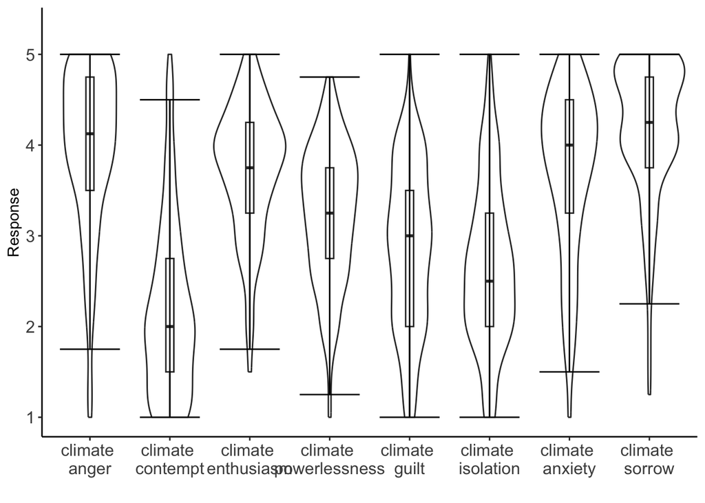

### Distribution of other variables

Inspect the distribution of the variables.

#### Formal test

```
## $`Climate anxiety: cognitive-emotional`
##
##  Shapiro-Wilk normality test
##
## data:  X[[i]]
## W = 0.86568, p-value = 0.000000000000001731
##
##
## $`Personal experience of cc`
##
##  Shapiro-Wilk normality test
##
## data:  X[[i]]
## W = 0.96885, p-value = 0.000004443
##
##
## $`Climate change beliefs`
##
##  Shapiro-Wilk normality test
##
## data:  X[[i]]
## W = 0.94866, p-value = 0.000000009815
##
##
## $`EAI: enjoyment of nature`
##
##  Shapiro-Wilk normality test
##
## data:  X[[i]]
## W = 0.76354, p-value < 0.00000000000000022
##
##
## $`EAI: support for policy`
##
##  Shapiro-Wilk normality test
##
## data:  X[[i]]
## W = 0.95017, p-value = 0.00000001467
##
##
```

[output cut: 151 more lines]

```
##
## $`Climate anxiety`
##
##  Shapiro-Wilk normality test
##
## data:  X[[i]]
## W = 0.92344, p-value = 0.00000000002815
##
##
## $`Climate sorrow`
##
##  Shapiro-Wilk normality test
##
## data:  X[[i]]
## W = 0.87294, p-value = 0.000000000000004871
```

For all but two variables p < .05 (except social desirability and PERS glob) so we have a reason to believe that most of our variables depart from normal distribution

#### Visual inspection

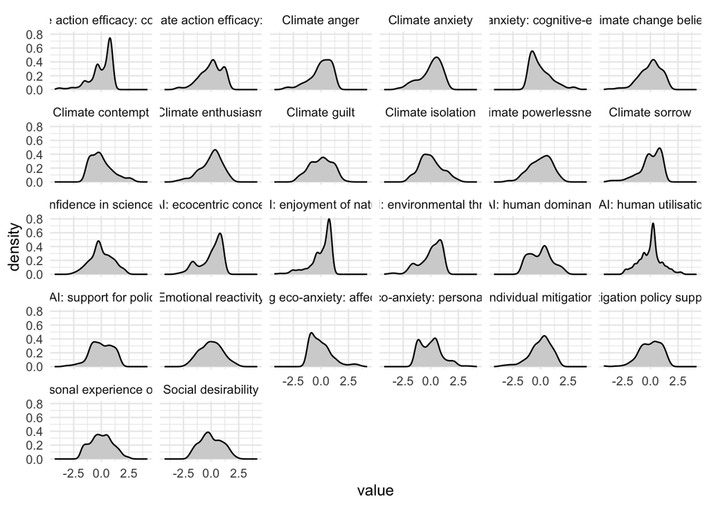

### Correlations

It’s time to compute the correlation coefficients. As the data deviates from the normal distribution and because it is ordinal anyways, let’s use Spearman correlation coefficients.

I will use the custom correlation_matrix function from Paul van der Laken (https://paulvanderlaken.com/2020/07/28/publication-ready-correlation-matrix-significance-r/#correlation_matrix)

#### Climate emotions inter-correlations

|  | climate.anger | climate.contempt | climate.enthusiasm | climate.powerlessness | climate.guilt | climate.isolation | climate.anxiety | climate.sorrow |
| --- | --- | --- | --- | --- | --- | --- | --- | --- |
| climate.anger |  |  |  |  |  |  |  |  |
| climate.contempt | -0.55*** |  |  |  |  |  |  |  |
| climate.enthusiasm | 0.38*** | -0.31*** |  |  |  |  |  |  |
| climate.powerlessness | 0.34*** | -0.05 | 0.00 |  |  |  |  |  |
| climate.guilt | 0.51*** | -0.36*** | 0.25*** | 0.45*** |  |  |  |  |
| climate.isolation | 0.37*** | -0.22*** | 0.13* | 0.37*** | 0.52*** |  |  |  |
| climate.anxiety | 0.69*** | -0.62*** | 0.39*** | 0.34*** | 0.60*** | 0.47*** |  |  |
| climate.sorrow | 0.74*** | -0.63*** | 0.39*** | 0.33*** | 0.51*** | 0.30*** | 0.73*** |  |

#### Correlations with other variables

|  | Climate anxiety: cognitive-emotional | Personal experience of cc | Climate change beliefs | EAI: enjoyment of nature | EAI: support for policy | EAI: confidence in science & tech | EAI: environmental threat | EAI: human dominance | EAI: human utilisation | EAI: ecocentric concern | Hogg eco-anxiety: affective | Hogg eco-anxiety: personal impact | Individual mitigation | Mitigation policy support | Climate action efficacy: self | Climate action efficacy: collective | Emotional reactivity | Social desirability | Climate anger | Climate contempt | Climate enthusiasm | Climate powerlessness | Climate guilt | Climate isolation | Climate anxiety | Climate sorrow |
| --- | --- | --- | --- | --- | --- | --- | --- | --- | --- | --- | --- | --- | --- | --- | --- | --- | --- | --- | --- | --- | --- | --- | --- | --- | --- | --- |
| Climate anxiety: cognitive-emotional |  |  |  |  |  |  |  |  |  |  |  |  |  |  |  |  |  |  |  |  |  |  |  |  |  |  |
| Personal experience of cc | 0.63*** |  |  |  |  |  |  |  |  |  |  |  |  |  |  |  |  |  |  |  |  |  |  |  |  |  |
| Climate change beliefs | 0.19*** | 0.48*** |  |  |  |  |  |  |  |  |  |  |  |  |  |  |  |  |  |  |  |  |  |  |  |  |
| EAI: enjoyment of nature | 0.08 | 0.22*** | 0.18** |  |  |  |  |  |  |  |  |  |  |  |  |  |  |  |  |  |  |  |  |  |  |  |
| EAI: support for policy | -0.08 | 0.13* | 0.27*** | 0.18** |  |  |  |  |  |  |  |  |  |  |  |  |  |  |  |  |  |  |  |  |  |  |
| EAI: confidence in science & tech | -0.01 | 0.04 | 0.08 | -0.02 | 0.05 |  |  |  |  |  |  |  |  |  |  |  |  |  |  |  |  |  |  |  |  |  |
| EAI: environmental threat | -0.05 | 0.27*** | 0.55*** | 0.27*** | 0.38*** | -0.01 |  |  |  |  |  |  |  |  |  |  |  |  |  |  |  |  |  |  |  |  |
| EAI: human dominance | 0.00 | -0.15* | -0.25*** | -0.11 | -0.18** | 0.09 | -0.30*** |  |  |  |  |  |  |  |  |  |  |  |  |  |  |  |  |  |  |  |
| EAI: human utilisation | -0.14* | -0.27*** | -0.42*** | -0.12* | -0.15** | -0.13* | -0.36*** | 0.27*** |  |  |  |  |  |  |  |  |  |  |  |  |  |  |  |  |  |  |
| EAI: ecocentric concern | 0.11 | 0.25*** | 0.37*** | 0.35*** | 0.16** | -0.04 | 0.40*** | -0.24*** | -0.25*** |  |  |  |  |  |  |  |  |  |  |  |  |  |  |  |  |  |
| Hogg eco-anxiety: affective | 0.69*** | 0.47*** | 0.18** | 0.05 | -0.01 | -0.04 | -0.01 | 0.00 | -0.11 | 0.08 |  |  |  |  |  |  |  |  |  |  |  |  |  |  |  |  |
| Hogg eco-anxiety: personal impact | 0.69*** | 0.59*** | 0.32*** | 0.15** | 0.02 | 0.02 | 0.13* | -0.06 | -0.22*** | 0.17** | 0.66*** |  |  |  |  |  |  |  |  |  |  |  |  |  |  |  |
| Individual mitigation | 0.05 | 0.23*** | 0.31*** | 0.24*** | 0.22*** | 0.11 | 0.30*** | -0.02 | -0.21*** | 0.22*** | 0.02 | 0.13* |  |  |  |  |  |  |  |  |  |  |  |  |  |  |
| Mitigation policy support | 0.16** | 0.33*** | 0.56*** | 0.17** | 0.32*** | 0.15* | 0.50*** | -0.30*** | -0.45*** | 0.34*** | 0.07 | 0.23*** | 0.27*** |  |  |  |  |  |  |  |  |  |  |  |  |  |
| Climate action efficacy: self | 0.17** | 0.38*** | 0.46*** | 0.19** | 0.18** | 0.16** | 0.34*** | -0.13* | -0.27*** | 0.26*** | 0.06 | 0.23*** | 0.38*** | 0.52*** |  |  |  |  |  |  |  |  |  |  |  |  |
| Climate action efficacy: collective | 0.12* | 0.31*** | 0.44*** | 0.28*** | 0.18** | 0.18** | 0.39*** | -0.10 | -0.26*** | 0.30*** | 0.03 | 0.19** | 0.35*** | 0.56*** | 0.70*** |  |  |  |  |  |  |  |  |  |  |  |
| Emotional reactivity | 0.25*** | 0.19*** | 0.22*** | 0.12* | 0.20*** | 0.05 | 0.20*** | -0.02 | 0.04 | 0.20*** | 0.33*** | 0.25*** | 0.02 | 0.19*** | 0.14* | 0.21*** |  |  |  |  |  |  |  |  |  |  |
| Social desirability | -0.03 | 0.07 | 0.06 | 0.27*** | 0.04 | 0.06 | 0.11 | -0.09 | -0.15* | 0.08 | -0.09 | 0.01 | 0.34*** | 0.09 | 0.21*** | 0.14* | -0.19** |  |  |  |  |  |  |  |  |  |
| Climate anger | 0.30*** | 0.48*** | 0.58*** | 0.19** | 0.28*** | 0.10 | 0.47*** | -0.23*** | -0.36*** | 0.39*** | 0.24*** | 0.42*** | 0.26*** | 0.60*** | 0.40*** | 0.47*** | 0.28*** | 0.06 |  |  |  |  |  |  |  |  |
| Climate contempt | -0.16** | -0.39*** | -0.66*** | -0.22*** | -0.30*** | -0.15** | -0.53*** | 0.33*** | 0.49*** | -0.38*** | -0.17** | -0.28*** | -0.26*** | -0.54*** | -0.45*** | -0.49*** | -0.21*** | -0.07 | -0.55*** |  |  |  |  |  |  |  |
| Climate enthusiasm | 0.24*** | 0.31*** | 0.27*** | 0.18** | 0.08 | 0.30*** | 0.20*** | 0.02 | -0.17** | 0.19*** | 0.08 | 0.28*** | 0.31*** | 0.41*** | 0.59*** | 0.66*** | 0.13* | 0.22*** | 0.38*** | -0.31*** |  |  |  |  |  |  |
| Climate powerlessness | 0.25*** | 0.15** | 0.14* | 0.05 | -0.01 | -0.11 | 0.06 | 0.04 | 0.03 | 0.19*** | 0.29*** | 0.34*** | -0.03 | 0.06 | -0.08 | 0.06 | 0.34*** | -0.24*** | 0.34*** | -0.05 | 0.00 |  |  |  |  |  |
| Climate guilt | 0.43*** | 0.40*** | 0.33*** | 0.04 | 0.11 | -0.04 | 0.15** | -0.13* | -0.25*** | 0.14* | 0.35*** | 0.53*** | 0.04 | 0.31*** | 0.25*** | 0.27*** | 0.25*** | -0.09 | 0.51*** | -0.36*** | 0.25*** | 0.45*** |  |  |  |  |
| Climate isolation | 0.50*** | 0.40*** | 0.24*** | 0.03 | -0.05 | -0.03 | -0.00 | -0.05 | -0.19*** | 0.18** | 0.44*** | 0.45*** | 0.06 | 0.17** | 0.18** | 0.10 | 0.22*** | 0.01 | 0.37*** | -0.22*** | 0.13* | 0.37*** | 0.52*** |  |  |  |
| Climate anxiety | 0.46*** | 0.59*** | 0.60*** | 0.23*** | 0.14* | 0.06 | 0.37*** | -0.17** | -0.35*** | 0.34*** | 0.39*** | 0.55*** | 0.29*** | 0.48*** | 0.47*** | 0.47*** | 0.31*** | 0.09 | 0.69*** | -0.62*** | 0.39*** | 0.34*** | 0.60*** | 0.47*** |  |  |
| Climate sorrow | 0.29*** | 0.47*** | 0.67*** | 0.28*** | 0.22*** | 0.10 | 0.45*** | -0.19*** | -0.34*** | 0.45*** | 0.23*** | 0.44*** | 0.29*** | 0.53*** | 0.45*** | 0.49*** | 0.32*** | 0.09 | 0.74*** | -0.63*** | 0.39*** | 0.33*** | 0.51*** | 0.30*** | 0.73*** |  |

## Discriminant validity

Let’s check if the scores on the ICE scales differ between groups that are expected to differ.

### Different levels of concern

Groups presenting different levels of climate change concern.

Let’s start from generating a plot to get an overview of the inter-group differences.

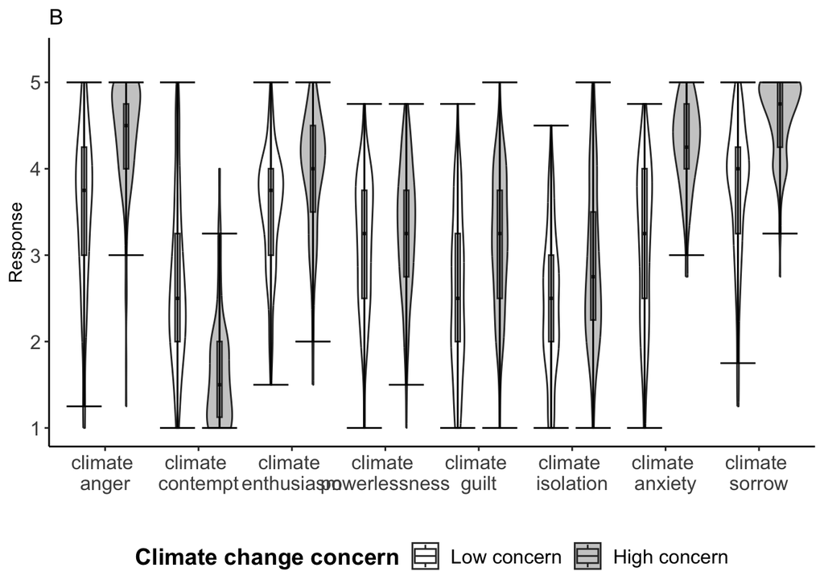

Time for a formal test.

Since the data deviates from normal distribution, let’s use non-parametric multivariate analysis of variance (NPMANOVA), also known as permutational multivariate analysis of variance (PERMANOVA). The hypothesis we’re testing is that climate emotions together are affected by the difference in the level of climate change concern.

```
## Permutation test for adonis under reduced model
## Terms added sequentially (first to last)
## Permutation: free
## Number of permutations: 999
##
## vegan::adonis2(formula = emo.only ~ concern.discriminant$concern.group, permutations = 999, method = "bray")
##                                     Df SumOfSqs      R2      F Pr(>F)
## concern.discriminant$concern.group   1   0.9184 0.21968 83.895  0.001 ***
## Residual                           298   3.2620 0.78032
## Total                              299   4.1804 1.00000
## ---
## Signif. codes:  0 '***' 0.001 '**' 0.01 '*' 0.05 '.' 0.1 ' ' 1
```

However, prior to concluding that a significant PERMANOVA test implies that the observed differences are in fact significant, we need to carry out another test: a test of homogeneity of dispersion - an analysis of multivariate homogeneity of group dispersions (variances), a multivariate analogue of Levene’s test for homogeneity of variances.

```
##
## Permutation test for homogeneity of multivariate dispersions
## Permutation: free
## Number of permutations: 999
##
## Response: Distances
##            Df  Sum Sq  Mean Sq      F N.Perm Pr(>F)
## Groups      1 0.09537 0.095365 40.036    999  0.001 ***
## Residuals 298 0.70983 0.002382
## ---
## Signif. codes:  0 '***' 0.001 '**' 0.01 '*' 0.05 '.' 0.1 ' ' 1
```

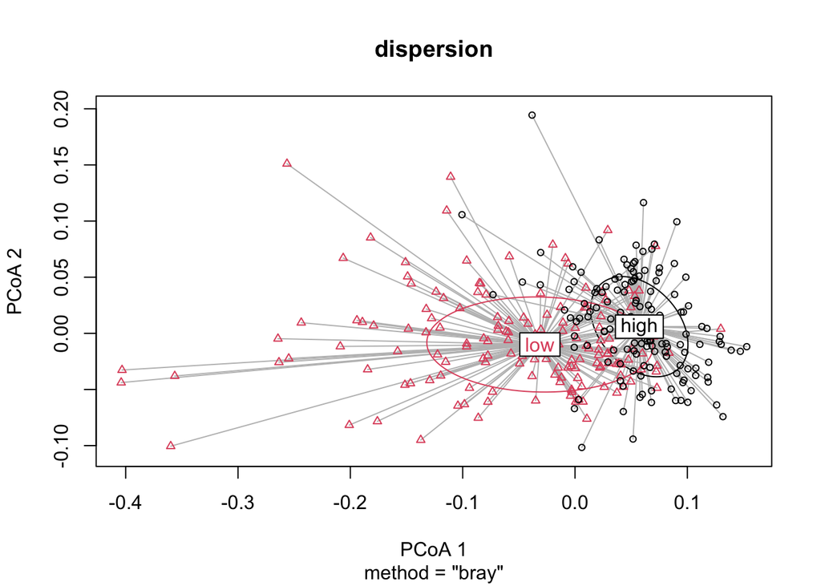

But which differences exactly are driving the overall difference between levels of concern about climate change? We can answer this question using the approximative (Monte Carlo) Fisher-Pitman test # https://www.researchgate.net/publication/11312045_The_Fisher-Pitman_Permutation_Test_An_Attractive_Alternative_to_the_F_Test

```
## $climate.anger
## [1] <0.00010001
## 99 percent confidence interval:
##  0.0000000000 0.0005297444
##
##
## $climate.contempt
## [1] <0.00010001
## 99 percent confidence interval:
##  0.0000000000 0.0005297444
##
##
## $climate.enthusiasm
## [1] <0.00010001
## 99 percent confidence interval:
##  0.0000000000 0.0005297444
##
##
## $climate.powerlessness
## [1] 0.05380538
## 99 percent confidence interval:
##  0.04815683 0.05988337
##
##
## $climate.guilt
## [1] <0.00010001
## 99 percent confidence interval:
##  0.0000000000 0.0005297444
##
##
## $climate.isolation
## [1] <0.00010001
## 99 percent confidence interval:
##  0.0000000000 0.0005297444
##
##
## $climate.anxiety
## [1] <0.00010001
## 99 percent confidence interval:
##  0.0000000000 0.0005297444
##
##
## $climate.sorrow
## [1] <0.00010001
## 99 percent confidence interval:
##  0.0000000000 0.0005297444
```

To control for false discovery rate, let’s adjust the empirical p-values with the Benjamini-Hochberg correction (#Westfall, P. H., & Young, S. S. (1993). Resampling-based multiple testing: Examples and methods for p-value adjustment (Vol. 279). John Wiley & Sons).

```
## [1] 0.0001142971 0.0001142971 0.0001142971 0.0505050500 0.0001142971 0.0001142971 0.0001142971 0.0001142971
```

### Genders

Now, let’s have a look at differences between men and women.

Let’s start from plotting the data to get an overview.

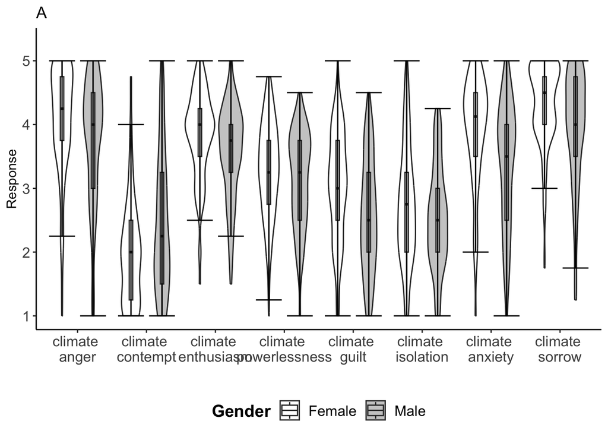

Now, let’s do a formal test, repeating the steps from the comparison between different levels of concern for climate change, but this time for gender.

```
## Permutation test for adonis under reduced model
## Terms added sequentially (first to last)
## Permutation: free
## Number of permutations: 999
##
## vegan::adonis2(formula = emo.only_gender ~ gender.discriminant$gender, permutations = 999, method = "bray")
##                             Df SumOfSqs      R2      F Pr(>F)
## gender.discriminant$gender   1   0.2098 0.05034 15.745  0.001 ***
## Residual                   297   3.9581 0.94966
## Total                      298   4.1679 1.00000
## ---
## Signif. codes:  0 '***' 0.001 '**' 0.01 '*' 0.05 '.' 0.1 ' ' 1
```

The null hypothesis of no differences in emotions between genders is strongly rejected. To conclude that a significant PERMANOVA test implies that the observed differences are in fact significant, we need to carry out a test of homogeneity of dispersion.

```
##
## Permutation test for homogeneity of multivariate dispersions
## Permutation: free
## Number of permutations: 999
##
## Response: Distances
##            Df  Sum Sq  Mean Sq      F N.Perm Pr(>F)
## Groups      1 0.03201 0.032007 9.3126    999  0.002 **
## Residuals 297 1.02079 0.003437
## ---
## Signif. codes:  0 '***' 0.001 '**' 0.01 '*' 0.05 '.' 0.1 ' ' 1
```

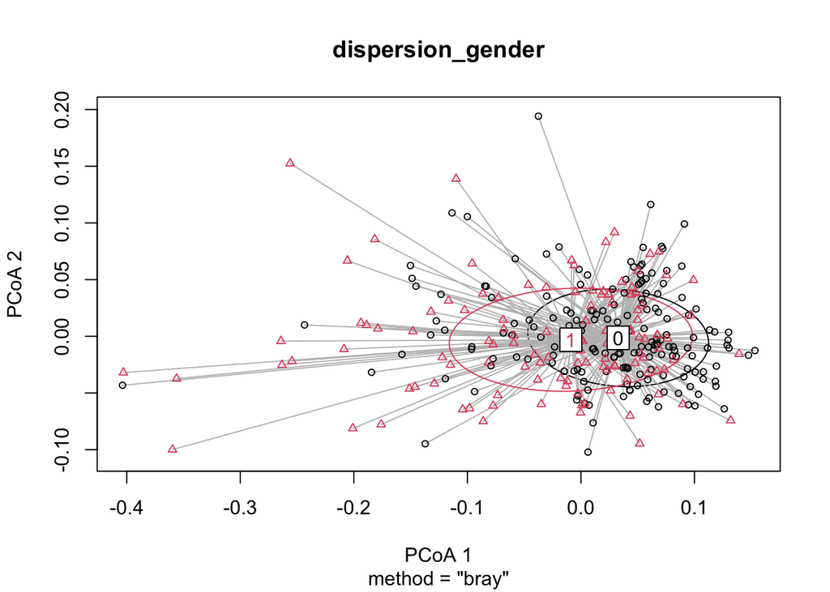

```
## $climate.anger
## [1] 0.00690069
## 99 percent confidence interval:
##  0.004953277 0.009331856
##
##
## $climate.contempt
## [1] 0.00010001
## 99 percent confidence interval:
##  0.0000005013042 0.0007428483734
##
##
## $climate.enthusiasm
## [1] 0.00060006
## 99 percent confidence interval:
##  0.0001537332 0.0015653677
##
##
## $climate.powerlessness
## [1] 0.06080608
## 99 percent confidence interval:
##  0.05481062 0.06722398
##
##
## $climate.guilt
## [1] <0.00010001
## 99 percent confidence interval:
##  0.0000000000 0.0005297444
##
##
## $climate.isolation
## [1] 0.05140514
## 99 percent confidence interval:
##  0.04588163 0.05736052
##
##
## $climate.anxiety
## [1] <0.00010001
## 99 percent confidence interval:
##  0.0000000000 0.0005297444
##
##
## $climate.sorrow
## [1] 0.00020002
## 99 percent confidence interval:
##  0.00001035095 0.00092713468
```

Let’s adjust the empirical p-values with the Benjamini-Hochberg correction.

```
## [1] 0.009467613 0.000200020 0.001600160 0.066206620 0.000200020 0.053833954 0.000200020 0.000200020
```

## Note

This HTML output presents the general logic of the analysis along with some results not outlined in the main body of the manuscript. Please note that the full R code for the data cleaning and data analysis is available in the supplementary materials on the accompanying [OSF website](https://osf.io/78d6u).